# Adaptive RAG (Adaptive Retrieval-Augmented Generation)

**Adaptive RAG** is an advanced agentic RAG paradigm that combines query analysis, dynamic routing, self-correction, and dual validation loops (hallucination grading & answer satisfaction).

Unlike standard RAG—which unconditionally searches the same vector index for every query—Adaptive RAG:

1. **Analyzes and routes the question** at entry: Domain-specific questions are routed to local vector retrieval, while broad or external knowledge questions are routed to live web search.
2. **Grades retrieved documents**: Filters out noise and evaluates document relevance.
3. **Reformulates queries if retrieval fails**: Rewrites the question to improve vector search precision.
4. **Applies dual-stage post-generation validation**:
   - **Hallucination Grader**: Validates whether the generated response is strictly grounded in the retrieved facts.
   - **Answer Grader**: Validates whether the response directly addresses the user's initial query. If not, it loops back to reformulate and re-retrieve!

## Workflow Architecture

[figure not shown]

**Click to expand Mermaid Source Code**

```
flowchart TD
    Start([User Question]) --> Router{"Question Router
Groq LLM"}

    Router -->|vectorstore| Retrieve["1. retrieve
Fetch docs from FAISS
(HuggingFace MiniLM)"]
    Router -->|web_search| WebSearch["Web Search
Fetch live results
(Tavily Search)"]

    Retrieve --> GradeDocs["2. grade_documents
Filter relevant docs
(Groq LLM Grader)"]

    GradeDocs --> DocDecision{"Any Docs
Relevant?"}
    DocDecision -->|Yes| Generate["3. generate
Synthesize answer
(Groq LLM RAG Chain)"]
    DocDecision -->|No: All Irrelevant| TransformQuery["4. transform_query
Rewrite question
(Groq LLM Rewriter)"]

    TransformQuery --> Retrieve
    WebSearch --> Generate

    Generate --> HallucinationGrader{"Hallucination Grader
Grounded in docs?
(Groq LLM)"}
    HallucinationGrader -->|No: Hallucinated| Generate
    HallucinationGrader -->|Yes: Grounded| AnswerGrader{"Answer Grader
Addresses question?
(Groq LLM)"}

    AnswerGrader -->|Yes: Useful| End([END: Final Answer])
    AnswerGrader -->|No: Not Useful| TransformQuery
```

### Key Architectural Strengths

- **Smart Routing**: Saves compute and latency by matching query complexity and domain to the optimal datasource.
- **Noise Resilience**: Eliminates irrelevant context chunks before they contaminate LLM generation.
- **Cyclic Self-Correction**: Implements automatic loops for query reformulation if retrieval or generation misses the mark.
- **Dual Factuality Guards**: Eliminates hallucinations and ensures strict grounding against retrieved context.

## Step 0: Environment Setup

Load API keys from a `.env` file. Ensure the following environment variables are configured:

- `GROQ_API_KEY` — Groq LLM API key
- `TAVILY_API_KEY` — Tavily Search API key
- `USER_AGENT` — Custom User-Agent header for document loaders

**Required Python packages:**

```
pip install langchain langchain-community langchain-groq langchain-huggingface \
            faiss-cpu langgraph python-dotenv pydantic tiktoken sentence-transformers
```

```python
import os
from dotenv import load_dotenv

# Load all environment variables from the .env file
load_dotenv()

# Set User-Agent to avoid WebBaseLoader warnings/blocks
os.environ['USER_AGENT'] = 'AdaptiveRAG/1.0'

# Expose required API keys to LangChain / Groq / Tavily
os.environ['GROQ_API_KEY'] = os.getenv('GROQ_API_KEY')         # Groq LLM API key
os.environ['TAVILY_API_KEY'] = os.getenv('TAVILY_API_KEY')     # Tavily web-search API key

print('Environment variables loaded successfully.')
```

```
Environment variables loaded successfully.
```

## Step 1: Build the Vector Index

We load authoritative web documents, split them into chunks, and store them in an in-memory **FAISS** vector store using **HuggingFace embeddings**.

- **Embeddings Model**: `sentence-transformers/all-MiniLM-L6-v2`
  - 384-dimensional dense semantic representations.
  - Runs **completely locally** on CPU/GPU without third-party API rate limits.
- **Document Sources**: Three seminal blog posts by Lilian Weng (LLM Agents, Prompt Engineering, Adversarial Attacks on LLMs).
- **Chunking**: `RecursiveCharacterTextSplitter.from_tiktoken_encoder` with `chunk_size=500` tokens and `chunk_overlap=0`.

```python
### Step 1 – Build Index

from langchain_text_splitters import RecursiveCharacterTextSplitter
from langchain_community.document_loaders import WebBaseLoader
from langchain_community.vectorstores import FAISS
from langchain_huggingface import HuggingFaceEmbeddings

# ------------------------------------------------------------------
# HuggingFace Embeddings
# sentence-transformers/all-MiniLM-L6-v2 characteristics:
#   - 384-dimensional dense vectors
#   - Fast, local, and highly effective for semantic retrieval
# ------------------------------------------------------------------
embedding = HuggingFaceEmbeddings(
    model_name='sentence-transformers/all-MiniLM-L6-v2'
)

# ------------------------------------------------------------------
# Source URLs to index
#   1. LLM-powered autonomous agents
#   2. Prompt engineering techniques
#   3. Adversarial attacks on LLMs
# ------------------------------------------------------------------
urls = [
    'https://lilianweng.github.io/posts/2023-06-23-agent/',
    'https://lilianweng.github.io/posts/2023-03-15-prompt-engineering/',
    'https://lilianweng.github.io/posts/2023-10-25-adv-attack-llm/',
]

# Load web documents
docs = [WebBaseLoader(url).load() for url in urls]
docs_list = [item for sublist in docs for item in sublist]

# ------------------------------------------------------------------
# Chunk documents for retrieval
# from_tiktoken_encoder counts tokens accurately using tiktoken
# ------------------------------------------------------------------
text_splitter = RecursiveCharacterTextSplitter.from_tiktoken_encoder(
    chunk_size=500,
    chunk_overlap=0
)
doc_splits = text_splitter.split_documents(docs_list)

# ------------------------------------------------------------------
# Build FAISS vector store
# ------------------------------------------------------------------
vectorstore = FAISS.from_documents(
    documents=doc_splits,
    embedding=embedding
)

# Expose retriever interface (default: top-4 similar chunks)
retriever = vectorstore.as_retriever()

print(f'Indexed {len(doc_splits)} document chunks into FAISS vector store.')
```

```
Indexed 88 document chunks into FAISS vector store.
```

## Step 2: Question Router

The **Question Router** is the front-door decision maker of Adaptive RAG. It assesses the user query and routes it to either:

1. `vectorstore`: If the question is about topics within our specialized indexed corpus (agents, prompt engineering, adversarial attacks).
2. `web_search`: If the question pertains to general knowledge, recent events, or topics outside our local knowledge base.
- **Structured Output**: Pydantic `RouteQuery` with `Literal["vectorstore", "web_search"]`.
- **Groq LLM**: `groq:openai/gpt-oss-120b` initialized via `init_chat_model`.

```python
### Step 2 – Question Router

from typing import Literal
from langchain.chat_models import init_chat_model
from langchain_core.prompts import ChatPromptTemplate
from pydantic import BaseModel, Field

# ------------------------------------------------------------------
# Pydantic schema for query routing
# ------------------------------------------------------------------
class RouteQuery(BaseModel):
    """Route a user query to the most relevant datasource."""

    datasource: Literal["vectorstore", "web_search"] = Field(
        ...,
        description="Given a user question choose to route it to web search or a vectorstore.",
    )

# ------------------------------------------------------------------
# Groq LLM — initialized via init_chat_model
# ------------------------------------------------------------------
llm = init_chat_model(model="groq:openai/gpt-oss-120b")

# System prompt defining routing criteria
system_router = (
    "You are an expert at routing a user question to a vectorstore or web search.\n"
    "The vectorstore contains documents related to agents, prompt engineering, and adversarial attacks on LLMs.\n"
    "Use the vectorstore for questions on these topics. For all other questions, use web_search."
)

route_prompt = ChatPromptTemplate.from_messages(
    [
        ("system", system_router),
        ("human", "{question}"),
    ]
)

# Chain: Prompt -> Groq structured LLM
question_router = route_prompt | llm.with_structured_output(RouteQuery)

# ------------------------------------------------------------------
# Sanity Tests: Test routing behavior for in-domain and out-of-domain queries
# ------------------------------------------------------------------
test_q1 = "What are the types of agent memory?"
test_q2 = "What is machine learning?"

route_1 = question_router.invoke({"question": test_q1})
route_2 = question_router.invoke({"question": test_q2})

print(f"Query: '{test_q1}' -> Routed to: {route_1.datasource}")
print(f"Query: '{test_q2}' -> Routed to: {route_2.datasource}")
```

```
Query: 'What are the types of agent memory?' -> Routed to: vectorstore
Query: 'What is machine learning?' -> Routed to: web_search
```

## Step 3: Retrieval Grader

The **Retrieval Grader** assesses whether each retrieved chunk is semantically relevant to the question.

- **Output**: Binary score — `'yes'` or `'no'`.
- Filters out irrelevant chunks to prevent context pollution during synthesis.

```python
### Step 3 – Retrieval Grader

# ------------------------------------------------------------------
# Pydantic schema for document relevance check
# ------------------------------------------------------------------
class GradeDocuments(BaseModel):
    """Binary score for relevance check on retrieved documents."""

    binary_score: str = Field(
        description="Document relevance to the question: 'yes' or 'no'"
    )

structured_llm_grader = llm.with_structured_output(GradeDocuments)

system_grader = (
    "You are a grader assessing relevance of a retrieved document to a user question.\n"
    "If the document contains keyword(s) or semantic meaning related to the question, grade it as relevant.\n"
    "Give a binary score 'yes' or 'no' to indicate whether the document is relevant."
)

grade_prompt = ChatPromptTemplate.from_messages(
    [
        ("system", system_grader),
        ("human", "Retrieved document:\n\n {document}\n\nUser question: {question}"),
    ]
)

retrieval_grader = grade_prompt | structured_llm_grader

# Quick sanity test
sample_q = "agent memory"
sample_docs = retriever.invoke(sample_q)
sample_result = retrieval_grader.invoke(
    {"question": sample_q, "document": sample_docs[0].page_content}
)
print(f"Grading result for sample document: {sample_result}")
```

```
Grading result for sample document: binary_score='no'
```

## Step 4: RAG Generation Chain

The **Generation Chain** synthesizes a concise, grounded answer from the verified context documents.

- **Prompt**: Standard grounded QA template requiring strict adherence to context.
- **Output**: Direct string response via `StrOutputParser()`.

```python
### Step 4 – RAG Generation Chain

from langchain_core.output_parsers import StrOutputParser

# ------------------------------------------------------------------
# Grounded QA prompt
# ------------------------------------------------------------------
prompt = ChatPromptTemplate.from_template(
    """You are an assistant for question-answering tasks. Use the following pieces of retrieved context to answer the question. If you don't know the answer, just say that you don't know. Use three sentences maximum and keep the answer concise.
Question: {question}
Context: {context}
Answer:"""
)


def format_docs(docs):
    """Safely format a list of documents or strings into a single text block."""
    if isinstance(docs, str):
        return docs
    if hasattr(docs, "page_content"):
        return docs.page_content
    return "\n\n".join(
        doc.page_content if hasattr(doc, "page_content") else str(doc)
        for doc in docs
    )


# Chain: prompt -> Groq LLM -> string
rag_chain = prompt | llm | StrOutputParser()

# Test generation with sample retrieved docs
sample_gen = rag_chain.invoke(
    {"context": format_docs(sample_docs), "question": sample_q}
)
print(f"Sample generation:\n{sample_gen}")
```

```
Sample generation:
In LLM‑powered agents, **short‑term memory** is the information the model can keep in‑context during a single prompt (the ~4 k‑token window). **Long‑term memory** is stored externally—typically in a vector database—so the agent can retrieve and reuse an unlimited amount of past observations, events,…
```

## Step 5: Hallucination Grader

The **Hallucination Grader** verifies factuality. It assesses whether the generated response is strictly grounded in and supported by the retrieved facts.

- **Output**: Binary score (`'yes'` = grounded, `'no'` = hallucinated / unsupported).
- If unsupported, the workflow can re-trigger generation.

```python
### Step 5 – Hallucination Grader


# ------------------------------------------------------------------
# Pydantic schema for hallucination assessment
# ------------------------------------------------------------------
class GradeHallucinations(BaseModel):
    """Binary score for hallucination present in generation answer."""

    binary_score: str = Field(
        description="Answer is grounded in the facts, 'yes' or 'no'"
    )


system_hallucination = (
    "You are a grader assessing whether an LLM generation is grounded in / supported by a set of retrieved facts.\n"
    "Give a binary score 'yes' or 'no'. 'yes' means that the answer is grounded in / supported by the set of facts."
)

hallucination_prompt = ChatPromptTemplate.from_messages(
    [
        ("system", system_hallucination),
        ("human", "Set of facts: \n\n {documents} \n\n LLM generation: {generation}"),
    ]
)

hallucination_grader = hallucination_prompt | llm.with_structured_output(GradeHallucinations)

# Sanity test
test_hallucination = hallucination_grader.invoke(
    {
        "documents": format_docs(sample_docs),
        "generation": sample_gen,
    }
)
print(f"Hallucination check result: {test_hallucination}")
```

```
Hallucination check result: binary_score='yes'
```

## Step 6: Answer Grader

The **Answer Grader** verifies utility. Even if an answer is grounded in facts, does it actually answer the user's specific question?

- **Output**: Binary score (`'yes'` = addresses question, `'no'` = fails to resolve question).
- If `'no'`, the workflow loops to rewrite the query and re-retrieve!

```python
### Step 6 – Answer Grader


# ------------------------------------------------------------------
# Pydantic schema for answer relevance
# ------------------------------------------------------------------
class GradeAnswer(BaseModel):
    """Binary score to assess answer addresses question."""

    binary_score: str = Field(
        description="Answer addresses the question, 'yes' or 'no'"
    )


system_answer = (
    "You are a grader assessing whether an answer addresses / resolves a question.\n"
    "Give a binary score 'yes' or 'no'. 'yes' means that the answer resolves the question."
)

answer_prompt = ChatPromptTemplate.from_messages(
    [
        ("system", system_answer),
        ("human", "User question: \n\n {question} \n\n LLM generation: {generation}"),
    ]
)

answer_grader = answer_prompt | llm.with_structured_output(GradeAnswer)

# Sanity test
test_answer_grade = answer_grader.invoke(
    {
        "question": sample_q,
        "generation": sample_gen,
    }
)
print(f"Answer utility check result: {test_answer_grade}")
```

```
Answer utility check result: binary_score='yes'
```

## Step 7: Question Re-writer

When retrieval fails to find relevant documents, or when an answer fails the Answer Grader, the **Question Re-writer** reformulates the query to better uncover semantic concepts in the vectorstore.

```python
### Step 7 – Question Re-writer

system_rewriter = (
    "You are a question re-writer that converts an input question to a better version that is optimized\n"
    "for vectorstore retrieval. Look at the input and try to reason about the underlying semantic intent / meaning."
)

re_write_prompt = ChatPromptTemplate.from_messages(
    [
        ("system", system_rewriter),
        (
            "human",
            "Here is the initial question:\n\n {question} \n Formulate an improved question.",
        ),
    ]
)

question_rewriter = re_write_prompt | llm | StrOutputParser()

# Test rewriting
rewritten_test = question_rewriter.invoke({"question": "agent memory"})
print(f"Original : agent memory")
print(f"Rewritten: {rewritten_test}")
```

```
Original : agent memory
Rewritten: **Improved question:**
What techniques and architectures are commonly used to implement long‑term memory in autonomous AI agents, and how can the stored information be efficiently retrieved and utilized during the agent’s decision‑making process?
```

## Step 8: Web Search Tool

When the Question Router flags a question as outside the vectorstore's domain, we leverage **Tavily Search** to gather live context from the web.

- Returns top-3 search results per query.

```python
### Step 8 – Web Search Tool

from langchain_community.tools.tavily_search import TavilySearchResults

# Initialise Tavily Search tool (k=3 results)
web_search_tool = TavilySearchResults(k=3)

print("Tavily web search tool initialised.")
```

```
Tavily web search tool initialised.
```

## Step 9: Define Graph State

The `GraphState` typed dictionary represents the shared state passed between all nodes in the LangGraph workflow.

| Field | Type | Description |
| --- | --- | --- |
| `question` | `str` | User question (or rewritten question) |
| `generation` | `str` | Synthesized LLM answer |
| `documents` | `List[Document]` | Retrieved or web-searched document chunks |

```python
### Step 9 – Graph State

from typing import List
from typing_extensions import TypedDict
from langchain_core.documents import Document


class GraphState(TypedDict):
    """
    Represents the state of our Adaptive RAG graph.

    Attributes:
        question: User question
        generation: LLM generation
        documents: List of retrieved / filtered documents
    """

    question: str
    generation: str
    documents: List[Document]
```

## Step 10: Define Graph Nodes and Conditional Edges

### Nodes

- **`retrieve`**: Queries the FAISS vector store for candidate chunks.
- **`grade_documents`**: Evaluates each retrieved chunk with `retrieval_grader` and retains only relevant ones.
- **`generate`**: Synthesizes the answer using `rag_chain`.
- **`transform_query`**: Rewrites the query to improve retrieval.
- **`web_search`**: Performs Tavily web search and packs results into a `Document` object.

### Conditional Routing Edges

- **`route_question`**: Entry edge from `START` -> routes to `vectorstore` (`retrieve`) or `web_search`.
- **`decide_to_generate`**: After grading -> if all docs filtered out, routes to `transform_query`; otherwise routes to `generate`.
- **`grade_generation_v_documents_and_question`**: After generation -> verifies grounding (hallucination) and utility (answer check):
  - Grounded & answers question -> `END`.
  - Not grounded -> retry `generate`.
  - Does not answer question -> `transform_query` to retry retrieval.

```python
### Step 10 – Node Functions and Conditional Edges


# ── NODE 1: retrieve ───────────────────────────────────────────────────────────
def retrieve(state):
    """
    Retrieve documents from the vector store.
    """
    print("---RETRIEVE---")
    question = state["question"]

    documents = retriever.invoke(question)
    return {"documents": documents, "question": question}


# ── NODE 2: generate ───────────────────────────────────────────────────────────
def generate(state):
    """
    Generate answer using RAG generation chain.
    """
    print("---GENERATE---")
    question = state["question"]
    documents = state["documents"]

    generation = rag_chain.invoke(
        {"context": format_docs(documents), "question": question}
    )
    return {"documents": documents, "question": question, "generation": generation}


# ── NODE 3: grade_documents ───────────────────────────────────────────────────
def grade_documents(state):
    """
    Determines whether the retrieved documents are relevant to the question.
    """
    print("---CHECK DOCUMENT RELEVANCE TO QUESTION---")
    question = state["question"]
    documents = state["documents"]

    filtered_docs = []
    for d in documents:
        score = retrieval_grader.invoke(
            {"question": question, "document": d.page_content}
        )
        grade = score.binary_score
        if grade == "yes":
            print("---GRADE: DOCUMENT RELEVANT---")
            filtered_docs.append(d)
        else:
            print("---GRADE: DOCUMENT NOT RELEVANT---")
            continue
    return {"documents": filtered_docs, "question": question}


# ── NODE 4: transform_query ───────────────────────────────────────────────────
def transform_query(state):
    """
    Transform the query to produce a better question for retrieval.
    """
    print("---TRANSFORM QUERY---")
    question = state["question"]
    documents = state.get("documents", [])

    better_question = question_rewriter.invoke({"question": question})
    return {"documents": documents, "question": better_question}


# ── NODE 5: web_search ────────────────────────────────────────────────────────
def web_search(state):
    """
    Web search based on the question.
    """
    print("---WEB SEARCH---")
    question = state["question"]

    docs = web_search_tool.invoke({"query": question})
    web_results = "\n".join([d["content"] for d in docs])
    web_doc = Document(page_content=web_results)

    return {"documents": [web_doc], "question": question}


# ── CONDITIONAL EDGE 1: route_question ─────────────────────────────────────────
def route_question(state):
    """
    Route question to web search or vectorstore.
    """
    print("---ROUTE QUESTION---")
    question = state["question"]
    source = question_router.invoke({"question": question})
    if source.datasource == "web_search":
        print("---ROUTE QUESTION TO WEB SEARCH---")
        return "web_search"
    elif source.datasource == "vectorstore":
        print("---ROUTE QUESTION TO RAG---")
        return "vectorstore"


# ── CONDITIONAL EDGE 2: decide_to_generate ─────────────────────────────────────
def decide_to_generate(state):
    """
    Determines whether to generate an answer, or re-generate a question.
    """
    print("---ASSESS GRADED DOCUMENTS---")
    filtered_documents = state["documents"]

    if not filtered_documents:
        print(
            "---DECISION: ALL DOCUMENTS ARE NOT RELEVANT TO QUESTION, TRANSFORM QUERY---"
        )
        return "transform_query"
    else:
        print("---DECISION: GENERATE---")
        return "generate"


# ── CONDITIONAL EDGE 3: grade_generation_v_documents_and_question ──────────────
def grade_generation_v_documents_and_question(state):
    """
    Determines whether the generation is grounded in the document and answers question.
    """
    print("---CHECK HALLUCINATIONS---")
    question = state["question"]
    documents = state["documents"]
    generation = state["generation"]

    score = hallucination_grader.invoke(
        {"documents": format_docs(documents), "generation": generation}
    )
    grade = score.binary_score

    # Check hallucination
    if grade == "yes":
        print("---DECISION: GENERATION IS GROUNDED IN DOCUMENTS---")
        # Check question-answering
        print("---GRADE GENERATION vs QUESTION---")
        score = answer_grader.invoke({"question": question, "generation": generation})
        grade = score.binary_score
        if grade == "yes":
            print("---DECISION: GENERATION ADDRESSES QUESTION---")
            return "useful"
        else:
            print("---DECISION: GENERATION DOES NOT ADDRESS QUESTION---")
            return "not useful"
    else:
        print("---DECISION: GENERATION IS NOT GROUNDED IN DOCUMENTS, RE-TRY---")
        return "not supported"
```

## Step 11: Build and Compile the LangGraph Workflow

We construct the `StateGraph`, register all 5 nodes, connect the conditional edges for dynamic routing and self-correction, and compile the executable application.

```
LangGraph Adaptive RAG workflow compiled successfully.
```

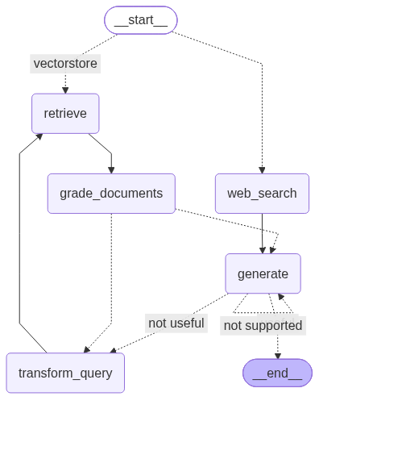

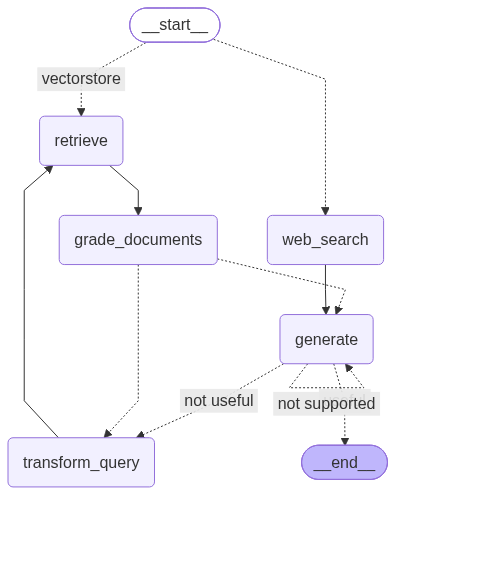

```python
### Step 11 – Build and Compile the LangGraph Workflow

from langgraph.graph import END, StateGraph, START
from IPython.display import Image, display

# Initialize workflow
workflow = StateGraph(GraphState)

# ── Add Nodes ──────────────────────────────────────────────────────────────────
workflow.add_node("web_search", web_search)            # Node: Web search
workflow.add_node("retrieve", retrieve)                # Node: Vectorstore retrieval
workflow.add_node("grade_documents", grade_documents)  # Node: Doc relevance grader
workflow.add_node("generate", generate)                # Node: RAG generator
workflow.add_node("transform_query", transform_query)  # Node: Query reformulator

# ── Add Edges ──────────────────────────────────────────────────────────────────
# Entry routing: START -> Web Search OR Vectorstore Retrieval
workflow.add_conditional_edges(
    START,
    route_question,
    {
        "web_search": "web_search",
        "vectorstore": "retrieve",
    },
)

# Web search path: web_search -> generate
workflow.add_edge("web_search", "generate")

# Vectorstore path: retrieve -> grade_documents
workflow.add_edge("retrieve", "grade_documents")

# Post-grading routing: relevant docs -> generate, all irrelevant -> transform_query
workflow.add_conditional_edges(
    "grade_documents",
    decide_to_generate,
    {
        "transform_query": "transform_query",
        "generate": "generate",
    },
)

# Cyclic query rewrite: transform_query loops back to retrieve!
workflow.add_edge("transform_query", "retrieve")

# Post-generation dual validation:
# - not supported (hallucinated) -> retry generate
# - useful (grounded & answers question) -> END
# - not useful (grounded but doesn't answer question) -> transform_query
workflow.add_conditional_edges(
    "generate",
    grade_generation_v_documents_and_question,
    {
        "not supported": "generate",
        "useful": END,
        "not useful": "transform_query",
    },
)

# Compile into runnable graph
app = workflow.compile()
print("LangGraph Adaptive RAG workflow compiled successfully.\n")

# Display the compiled execution graph
display(Image(app.get_graph().draw_mermaid_png()))
app
```

## Step 12: Run the Adaptive RAG Pipeline

We execute the compiled graph on two distinct test cases to demonstrate both routing pathways:

1. **Out-of-Domain Query**: `"What is machine learning"` -> Routed to **Web Search** -> Generated -> Validated -> `END`.
2. **Domain-Specific Query**: `"What is agent memory"` -> Routed to **Vectorstore Retrieval** -> Relevance Graded -> Generated -> Hallucination Checked -> Answer Checked -> `END`.

```python
### Step 12 – Run the Adaptive RAG Pipeline

# ------------------------------------------------------------------
# Test Case 1: Out-of-domain query (triggers Web Search)
# ------------------------------------------------------------------
print("=" * 70)
print("TEST CASE 1: Query outside vectorstore domain -> Web Search")
print("=" * 70)
q1 = "What is machine learning"
res1 = app.invoke({"question": q1})

print("\n" + "=" * 70)
print(f"FINAL ANSWER FOR: '{q1}'")
print("=" * 70)
print(res1["generation"])

# ------------------------------------------------------------------
# Test Case 2: In-domain query (triggers Vectorstore Retrieval + Grading)
# ------------------------------------------------------------------
print("\n" + "=" * 70)
print("TEST CASE 2: Query inside vectorstore domain -> FAISS Retrieval")
print("=" * 70)
q2 = "What is agent memory"
res2 = app.invoke({"question": q2})

print("\n" + "=" * 70)
print(f"FINAL ANSWER FOR: '{q2}'")
print("=" * 70)
print(res2["generation"])
```

```
======================================================================
TEST CASE 1: Query outside vectorstore domain -> Web Search
======================================================================
---ROUTE QUESTION---
```

```
---ROUTE QUESTION TO WEB SEARCH---
---WEB SEARCH---
```

```
---GENERATE---
```

```
---CHECK HALLUCINATIONS---
```

```
---DECISION: GENERATION IS GROUNDED IN DOCUMENTS---
---GRADE GENERATION vs QUESTION---
```

```
---DECISION: GENERATION ADDRESSES QUESTION---

======================================================================
FINAL ANSWER FOR: 'What is machine learning'
======================================================================
Machine learning is a subfield of artificial intelligence that enables computers to learn from data and improve their performance on tasks without being explicitly programmed. It involves training algorithms on datasets to create models that can make predictions, classify information, or generate ne…

======================================================================
TEST CASE 2: Query inside vectorstore domain -> FAISS Retrieval
======================================================================
---ROUTE QUESTION---
```

```
---ROUTE QUESTION TO RAG---
---RETRIEVE---
---CHECK DOCUMENT RELEVANCE TO QUESTION---
```

```
---GRADE: DOCUMENT NOT RELEVANT---
```

```
---GRADE: DOCUMENT RELEVANT---
```

```
---GRADE: DOCUMENT RELEVANT---
```

```
---GRADE: DOCUMENT RELEVANT---
---ASSESS GRADED DOCUMENTS---
---DECISION: GENERATE---
---GENERATE---
```

```
---CHECK HALLUCINATIONS---
```

```
---DECISION: GENERATION IS GROUNDED IN DOCUMENTS---
---GRADE GENERATION vs QUESTION---
```

```
---DECISION: GENERATION ADDRESSES QUESTION---

======================================================================
FINAL ANSWER FOR: 'What is agent memory'
======================================================================
Agent memory is the system that records an agent’s experiences as natural‑language observations (the “memory stream”) in a long‑term external store and retrieves them based on relevance, recency, and importance. It also includes a short‑term, in‑context memory that the LLM uses during a single inter…
```

## Summary

| Component | Technology | Role |
| --- | --- | --- |
| **Embeddings** | HuggingFace `sentence-transformers/all-MiniLM-L6-v2` | Dense 384-d semantic representations (local) |
| **Vector Store** | FAISS | In-memory similarity search |
| **LLM Engine** | Groq `openai/gpt-oss-120b` (`init_chat_model`) | Fast high-quality reasoning, grading, and synthesis |
| **Question Router** | Structured Groq LLM (`RouteQuery`) | Classifies queries to vectorstore vs web search |
| **Retrieval Grader** | Structured Groq LLM (`GradeDocuments`) | Eliminates irrelevant context chunks |
| **Hallucination Grader** | Structured Groq LLM (`GradeHallucinations`) | Enforces factual grounding |
| **Answer Grader** | Structured Groq LLM (`GradeAnswer`) | Enforces query resolution |
| **Question Re-writer** | Groq LLM Chain | Reformulates queries for better retrieval |
| **Web Search** | Tavily Search API | Live internet retrieval for general topics |
| **Orchestration** | LangGraph `StateGraph` | Cyclical graph with conditional routing and self-correction |

### Paradigm Comparison: Naive RAG vs CRAG vs Adaptive RAG

| Feature | Naive RAG | Corrective RAG (CRAG) | Adaptive RAG |
| --- | --- | --- | --- |
| **Query Routing** | None (always static retrieval) | None (always vector retrieval first) | **Dynamic** (Vectorstore vs Web Search at entry) |
| **Document Grading** | None | Yes (binary relevance check) | **Yes** (binary relevance check) |
| **Query Transformation** | None | Yes (rewrites for web search) | **Yes** (rewrites for vector retrieval retry) |
| **Hallucination Check** | None | None | **Yes** (grades generation vs documents) |
| **Answer Utility Check** | None | None | **Yes** (grades generation vs question) |
| **Graph Topology** | Linear DAG | Directed with fallback branch | **Cyclic Graph with Multiple Feedback Loops** |